# Developing data products final assignment

June 14, 2016

## Assignment

1. Create a Shiny application and deploy it on Rstudio's servers. Following included:
   - Some form of input (widget: textbox, radio button, checkbox, …)
   - Some operation on the ui input in sever.R
   - Some reactive output displayed as a result of server calculations
2. Prepare a reproducible pitch presentation about your application in Slidify. Following included:
   - 5 slides
   - Hosted on Github or Rpubs
   - Contains embedded R code

## Created application

*'The application should give users a better understanding about the distribution of their numeric data. The most common visualisation to do so is via histograms.'*

## Example of visualisations

You can upload any txt or csv file and select a column you wish to explore. An example of a histogram obtained in the shiny app is the following:

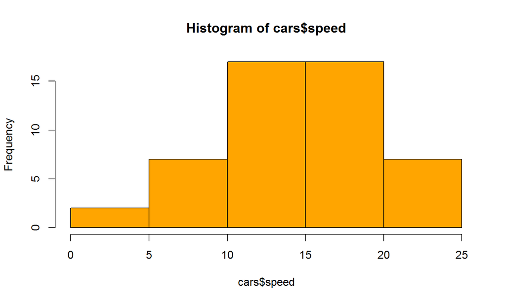

## Match with assignment

- **reactive**: the bins can be adjusted
- **input**: you can upload files, adjust csv settings and select columns
- **operation**: the application will read the data and create a histogram
- **slides**: this presentation only contains 5 slides
- **r chunk**: the histogram on the previous slide was created via a r chunk